# Amplitud del intervalo de confianza

Nicolás Molano Gonzalez

18 de Septiembre de 2018

En este documento exploraremos los factores que determinan la amplitud de un intervalo de confianza. Para efectos prácticos, haremos el análisis con el intervalo de confianza para el valor esperado. Recordemos cual es su formula.

# 1 Intervalo de confianza para el valor esperado

La formula del intervalo de confianza para el valor esperado es la siguiente:

$$\Bigg( \bar{X}-t_{n-1,1-\frac{\alpha}{2}}\times\frac{S}{\sqrt{n}},\bar{X}-t_{n-1,\frac{\alpha}{2}}\times\frac{S}{\sqrt{n}}\Bigg)$$

Donde:

- $\bar{X}$ es el promedio calculado con la muestra.
- $S$ es la desviación estándar calculada con la muestra.
- $n$ es el tamaño de la muestra y $\sqrt{n}$ su raíz cuadrada.
- $t_{n-1,\frac{\alpha}{2}}$ es el cuantil $\frac{\alpha}{2}$ de la distribución $T$ con $n-1$ grados de libertad.
- $t_{n-1,1-\frac{\alpha}{2}}$ es el cuantil $1-\frac{\alpha}{2}$ de la distribución $T$ con $n-1$ grados de libertad.

Por ejemplo en la figura se muestran los cuantiles $t_{70,0.025}=-1.994$ y $t_{70,0.975}=1.994$ para una distribución $T$ con $70$ grados de libertad. Es importante entender que el parametro grados de libertad cambia la forma de la curva, como se puede apreciar en la figura

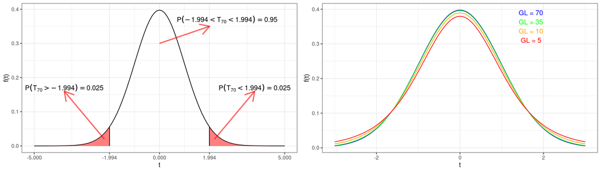

Al cambiar la forma de la curva, el valor de los cuantiles cambia también, como se puede apreciar en la siguiente tabla:

| GL | t_0.05 |
| --- | --- |
| 70 | -1.666915 |
| 35 | -1.689572 |
| 10 | -1.812461 |
| 5 | -2.015048 |

# 2 Factores que afectan la amplitud del intervalo de confianza

Al estudiar la formula del intervalo de confianza, observamos que existen tres cantidades que determinan su amplitud:

$$\Bigg( \bar{X}-t_{n-1,1-\frac{\alpha}{2}}\times\frac{S}{\sqrt{n}},\bar{X}-t_{n-1,\frac{\alpha}{2}}\times\frac{S}{\sqrt{n}}\Bigg)$$

El tamaño de la muestra $n$, El nivel de confianza (es decir $1-\alpha$) y la desviación estándar de los datos $S$. A continuación exploraremos el efecto de cada una de estas cantidades sobre la amplitud del intervalo.

## 2.1 Tamaño de la muestra

Considere la siguiente función de densidad del peso para una población en particular.

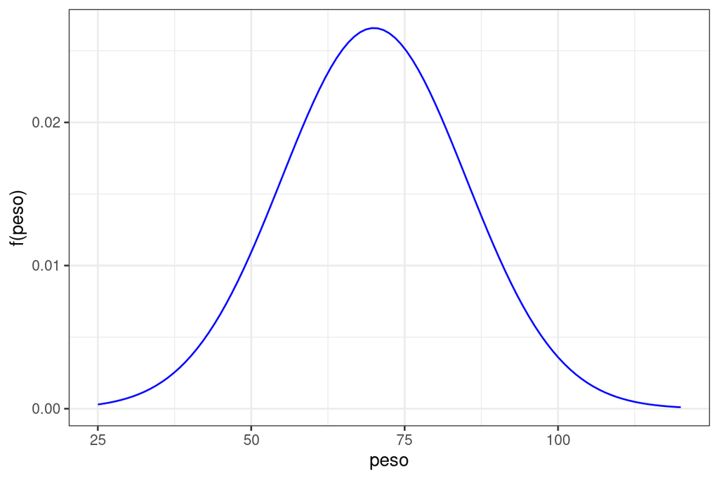

De esta población hipotética haremos diferentes muestreos con diferentes tamaños de muestra y calcularemos el intervalo de confianza para cada una. A continuación se presentan los histogramas para cada una de las muestras:

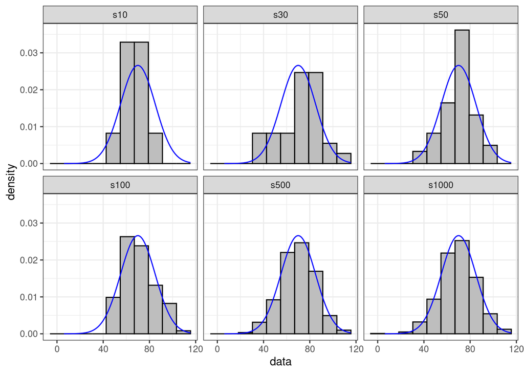

La curva azul es la verdadera función de densidad de la población. Ahora construimos los intervalos de confianza para cada muestra:

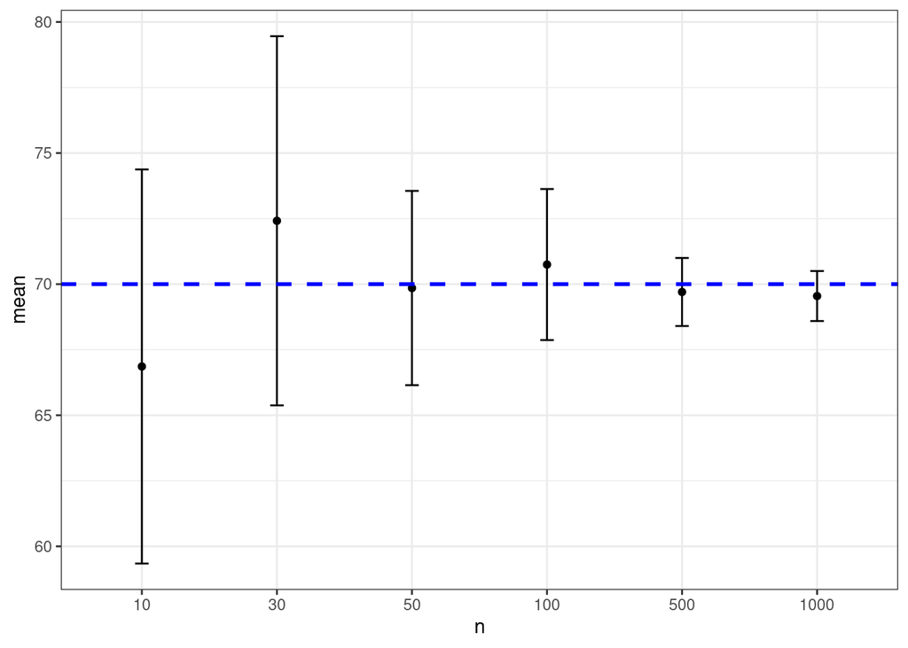

En azul se destaca el verdadero valor esperado de la población. Es claro que a mayor tamaño de muestra, la amplitud del intervalo de confianza disminuye.

## 2.2 Nivel de confianza

Para observar cual es el efecto del nivel de confianza en la amplitud del intervalo de confianza primero observemos lo siguiente:

- El nivel de confianza se define como $1-\alpha$ y los cuantiles que usamos para contruir el intervalo para el valor esperado están dados por $t_{n-1,\frac{\alpha}{2}}$ y $t_{n-1,1-\frac{\alpha}{2}}$, donde $n$ es el tamaño de la muestra.
- Veamos un ejemplo de esto: si el nivel de confianza es del 95%, esto quiere decir que $0.95 = 1-\alpha$ luego $\alpha =1-.95=0.05$. Ahora los cuantiles que debemos usar son $\frac{\alpha}{2}=0.05/2=0.025$ y $1-\frac{\alpha}{2}=1-\frac{0.05}{2}= 1-0.025=0.975$

A continuación presentamos una tabla con diferentes niveles de confianza, su correspondiente $\alpha$ y cuantiles.

| confianza | alpha | q_inf | q_sup |
| --- | --- | --- | --- |
| 0.90 | 0.10 | 0.050 | 0.950 |
| 0.92 | 0.08 | 0.040 | 0.960 |
| 0.94 | 0.06 | 0.030 | 0.970 |
| 0.95 | 0.05 | 0.025 | 0.975 |
| 0.99 | 0.01 | 0.005 | 0.995 |

Aquí q_inf corresponde a $\frac{\alpha}{2}$ y q_sup corresponde a $1-\frac{\alpha}{2}$.

Veamos ahora como se comportan los diferentes cuantiles dependiendo de los valores de confianza y $\alpha$:

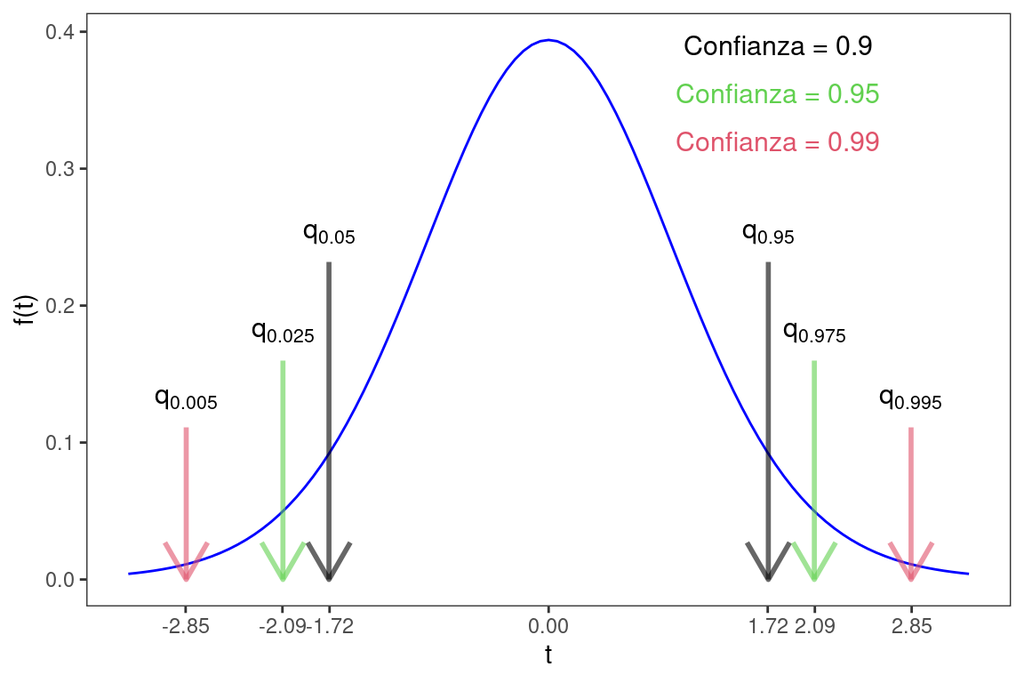

Es claro que a medida que la confianza aumenta, la distancia entre los correspondientes cuantiles también aumenta. Ahora veamos un ejemplo concreto de una muestra de pesos de una población particular en donde calculamos los intervalos con diferentes valores de confianza.

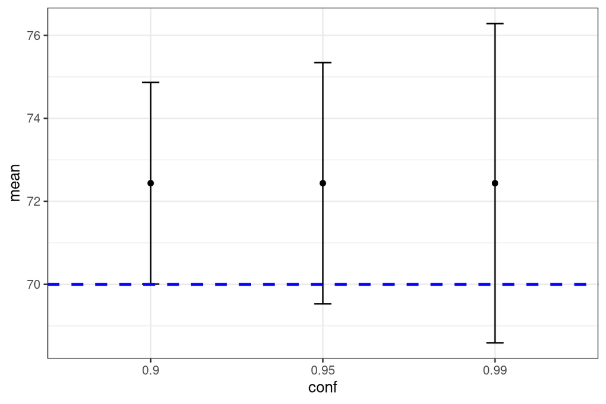

## 2.3 Varianza

Para observar cual es el efecto de la varianza en la amplitud del intervalo de confianza, estudiaremos varias poblaciones con diferentes varianzas:

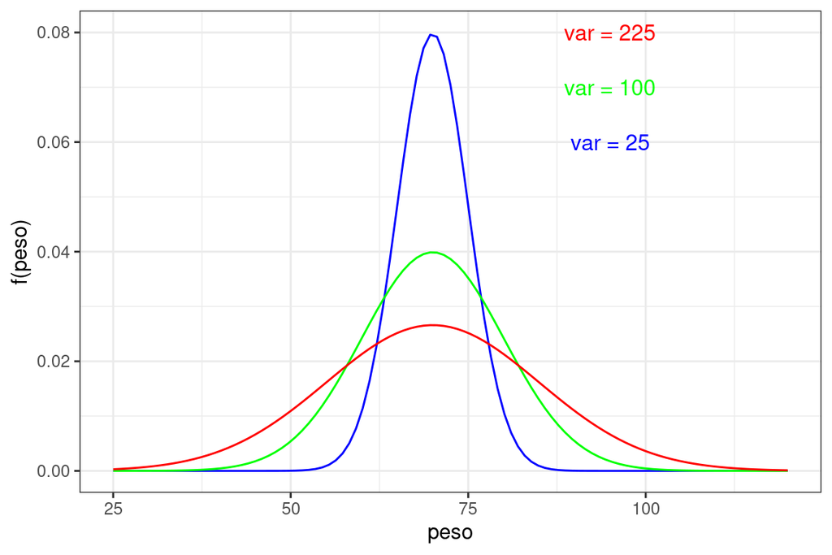

De cada población extraeremos muestras de tamaño 50. Aquí se observan los resultados:

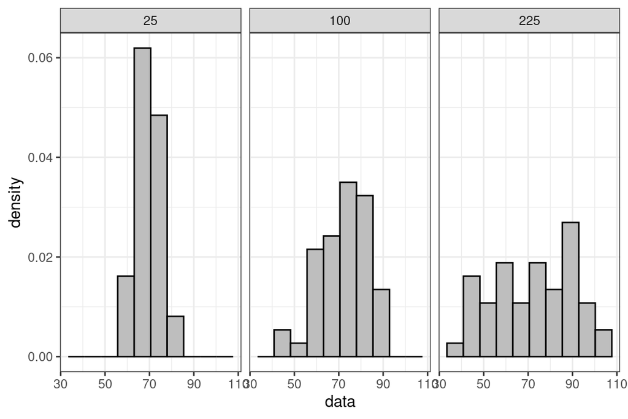

Ahora construiremos los intervalos de 95% de confianza para cada muestra:

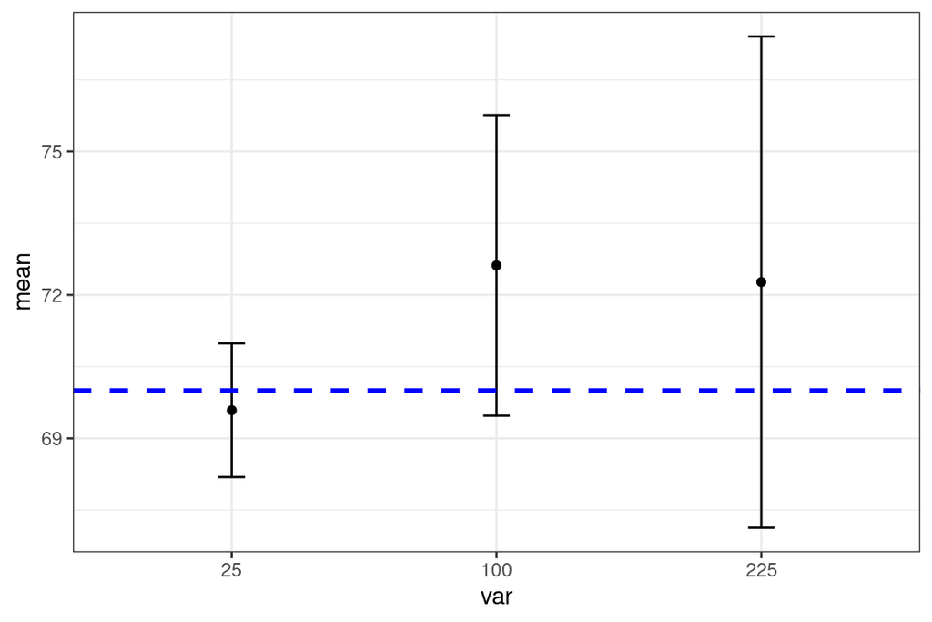

Es claro que a mayor varianza, mayor amplitud del intervalo